# Data-Dive-Week-13-Critiquing-Models-Analysis

Raghuveer Venkatesh

2024-11-26

# Goal 1: Business Scenario

- **Customer or Audience**: United Nation
- **Problem Statement**: UN has received an additional budget of $5M and has approached us as they would like a report on which countries this additional budget can be utilized to have maxiumum impact
- **Scope**: Population, GDP per ca-pita, Life Expectancy.
- **Objective**: Identify the top 5 countries where infusion of these funds can result in the highest increase of life expectancy.

## Goal 2: Model Critique

### Analysis 1: Countries most in need at present

#### Improvements

**This is a statistical improvement as Individual context matters.** This analysis aims to identify countries currently most in need of healthcare or economic interventions, using a country-specific approach that focuses on intrinsic data rather than regional or neighbor-based comparisons

We will first take the top 50 countries with the lowest life expectancy and GDP per ca-pita in the latest available year data.

Why this is important: * Lower GDP and life expectancy means that they have poor healthcare systems, inadequate nutrition and limited access to basic services. * Small investments may yield significant improvements in these countries because of the low baseline conditions.

Hence, This data helps to prioritize countries where the funds can have the greatest proportional impact.

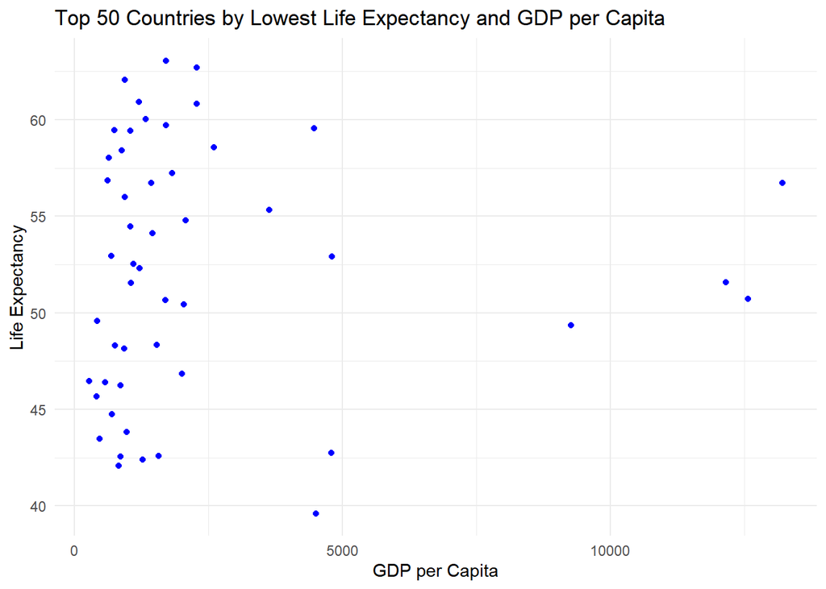

```r
alldata <- gapminder_unfiltered

latest_year_data <- gapminder_unfiltered |>
  filter(year == max(year))

countries_most_in_need_10 <- latest_year_data |>
  arrange(lifeExp, gdpPercap) |>
  head(50) |>
  select(country,continent,lifeExp,gdpPercap,pop, year)


ggplot(countries_most_in_need_10, aes(x = gdpPercap, y = lifeExp)) +
  geom_point(color = "blue") +   # Blue points for simplicity
  labs(
    title = "Top 50 Countries by Lowest Life Expectancy and GDP per Capita",
    x = "GDP per Capita",
    y = "Life Expectancy"
  ) +
  theme_minimal()
```

```r
print(head(countries_most_in_need_10))
```

```
## # A tibble: 6 × 6
##   country      continent lifeExp gdpPercap      pop  year
##   <fct>        <fct>       <dbl>     <dbl>    <int> <int>
## 1 Swaziland    Africa       39.6     4513.  1133066  2007
## 2 Mozambique   Africa       42.1      824. 19951656  2007
## 3 Zambia       Africa       42.4     1271. 11746035  2007
## 4 Sierra Leone Africa       42.6      863.  6144562  2007
## 5 Lesotho      Africa       42.6     1569.  2012649  2007
## 6 Angola       Africa       42.7     4797. 12420476  2007
```

50% gdp per ca-pita and 50% life expectancy

```r
# Combine GDP per capita and life expectancy using weighted sum
top_50_countries <- countries_most_in_need_10 |>
  mutate(combined_score = 0.5 * gdpPercap + 0.5 * lifeExp) |>
  arrange(combined_score)

print(top_50_countries)
```

```
## # A tibble: 50 × 7
##    country               continent lifeExp gdpPercap    pop  year combined_score
##    <fct>                 <fct>       <dbl>     <dbl>  <int> <int>          <dbl>
##  1 Congo, Dem. Rep.      Africa       46.5      278. 6.46e7  2007           162.
##  2 Liberia               Africa       45.7      415. 3.19e6  2007           230.
##  3 Burundi               Africa       49.6      430. 8.39e6  2007           240.
##  4 Zimbabwe              Africa       43.5      470. 1.23e7  2007           257.
##  5 Guinea-Bissau         Africa       46.4      579. 1.47e6  2007           313.
##  6 Niger                 Africa       56.9      620. 1.29e7  2007           338.
##  7 Eritrea               Africa       58.0      641. 4.91e6  2007           350.
##  8 Ethiopia              Africa       52.9      691. 7.65e7  2007           372.
##  9 Central African Repu… Africa       44.7      706. 4.37e6  2007           375.
## 10 Malawi                Africa       48.3      759. 1.33e7  2007           404.
## # ℹ 40 more rows
```

#### Observations

We could identify that the majority of the low GDP and low expectancy countries are in Africa and Myanmar and Afganistan outside of Africa.

### Analysis 1.2: Pearson-R co-efficient to measure the correlation between GDP per capita and life expectancy

This is necessary because if the life expectancy doesn’t increase with GDP per ca-pita then we have correctly weighed them by giving 50-50 weightage. But if they have a strong correlation then we can give a higher weight to life expectancy as that is one of the main variables we are trying to maximize.

```r
correlation <- cor(top_50_countries$gdpPercap, top_50_countries$lifeExp)
print(paste("Correlation between GDP and Life Expectancy is ",correlation))
```

```
## [1] "Correlation between GDP and Life Expectancy is  0.0252053612609126"
```

There is a weak correlation between the two so it doesn’t make sense to adjust the weightage.

So we can keep it at 50:50

#### Improvements

**This is a statistical improvement as a combined score of life expectancy and gdp is a more robust metric for analysis than assessing them independently as was done in the Week 6 notebook**

It gives a more holistic evaluation of the current situation of the countries.

[figure not shown]

```r
top_20_countries <- top_50_countries |> arrange(combined_score) |> head(20)

yearly_improvement <- gapminder_unfiltered |>
  group_by(country) |>
  arrange(country, year) |>
  mutate(life_expectancy_change = lifeExp - lag(lifeExp)) |>
  filter(country %in% top_20_countries$country) |>
  filter(!is.na(life_expectancy_change))




ggplot(yearly_improvement, aes(x = year, y = lifeExp, color = country)) +
  geom_line(size = 0.5) +
  geom_point(aes(size = abs(life_expectancy_change)), alpha = 1) +
  labs(
    title = "Yearly Improvement in Life Expectancy for Bottom 10 Countries",
    x = "Year",
    y = "Life Expectancy",
    color = "Country"
  ) +
  theme_minimal() +
  theme(legend.position = "left") +
  scale_size_continuous(name = "Yearly Change Magnitude")
```

```r
top_20_countries <- yearly_improvement  |> summarise(total_improvement = sum(life_expectancy_change, na.rm = TRUE)) |> arrange(total_improvement)

print(top_20_countries)
```

```
## # A tibble: 20 × 2
##    country                  total_improvement
##    <fct>                                <dbl>
##  1 Zimbabwe                             -4.96
##  2 Rwanda                                6.24
##  3 Liberia                               7.20
##  4 Congo, Dem. Rep.                      7.32
##  5 Central African Republic              9.28
##  6 Burundi                              10.5
##  7 Mozambique                           10.8
##  8 Malawi                               12.0
##  9 Sierra Leone                         12.2
## 10 Guinea-Bissau                        13.9
## 11 Afghanistan                          15.0
## 12 Somalia                              15.2
## 13 Ethiopia                             18.9
## 14 Niger                                19.4
## 15 Togo                                 19.8
## 16 Mali                                 20.8
## 17 Eritrea                              22.1
## 18 Guinea                               22.4
## 19 Myanmar                              25.8
## 20 Gambia                               29.4
```

```r
countries_needing_help <- merge(top_20_countries, top_50_countries, by="country")
```

#### Observations

We could see that Zimbabwe has reduced life expectancy and the other countries have shown minimal improvement in comparison.So we can recommend the following countries to the UN

- Zimbabwe
- Rwanda
- Liberia
- Dem Rep Congo
- Central African Republic

### Analysis 3: Bootstrapping the data and estimating the confidence intervals

We do this so we can assess the uncertainty in the combined scores and provide estimates for improvements.

#### Improvements

**We consider the combined score for bootstrapping rather than the individual columns which will give a more whole image of how accurate our metric of improvement index is**

**We have also improved the visualization previously adding the magnitude of the change in the life expectancy and taking the absolute change in life expectancy as bubbles**

[figure not shown]

```r
countries_of_interest <- data.frame(
  country = c("Zimbabwe", "Rwanda", "Liberia", "Democratic Republic of Congo", "Central African Republic")
)

bootstrap_input_data <- gapminder |>
  filter(country %in% countries_of_interest$country) |>
  mutate(combined_score = 0.5 * gdpPercap + 0.5 * lifeExp) |>
  arrange(combined_score)

n_iterations <- 100

bootstrap_results <- replicate(n_iterations, {
  resampled_data <- bootstrap_input_data[sample(nrow(bootstrap_input_data), replace = TRUE), ]
  mean_combined_score <- mean(resampled_data$combined_score, na.rm = FALSE)
  return(mean_combined_score)
})


ci_lower <- quantile(bootstrap_results, 0.025, na.rm = TRUE)
ci_upper <- quantile(bootstrap_results, 0.975, na.rm = TRUE)

bootstrap_df <- data.frame(bootstrap_results)

ggplot(bootstrap_df, aes(x = bootstrap_results)) +
  geom_histogram(bins = 30, fill = "skyblue", color = "black") +
  geom_vline(aes(xintercept = ci_lower), color = "red", linetype = "dashed") +
  geom_vline(aes(xintercept = ci_upper), color = "red", linetype = "dashed") +
  labs(
    title = "Bootstrap Distribution of Combined Scores for Recommended Countries",
    x = "Combined Score",
    y = "Frequency"
  ) +
  theme_minimal()
```

### Observation

The confidence interval is more spread out so there is a slight amount of uncertainty and additional data might be required to reliably use this data.

## Goal 3: Ethical and Epistemological Concerns

#### Data Risks

- Data collection might be incomplete or skewed due to under-reporting in low-resource countries.
- Many other key metrics are missing in the data set which can paint a more clear picture like mortality rate by specific age group and infant mortality rates.

#### Risks

- Prioritizing already improving nations night neglect stagnant or regressive countries in need of immediate intervention if we are wrong.
- GDP and life expectancy metrics may be too broad to understand ground reality in the countries analyzed.

#### Analytical risks

- This analysis only focus on GDP, Avg. Life expendency but these are not the accurate measures of standard of life and their health services.

#### Crucial issues that cannot be measured.

- Political instability or conflict impacts healthcare and economic indicators but cannot be measured.
- History of the country which has led to these conditions cannot be measured.

### Who would be impacted by this project ?

- Citizens of the respective countries
- NGOs in the respective countries
- AID organizations

### Critical Evaluation and Recommendations

- Work with local government when delivering aid
- Impact evaluation after aid is delivered
- ethical handling of the health data.
- Additional data collection like age demographics etc., which can be used to improve our future analysis